# Práctica 2: Limpieza y validación de los datos

ANTONIO SANCHEZ NAVARRO

23 de diciembre 2018

# 1 Carga de los datos

En esta actividad se usará el fichero winequality-red.csv del repositorio Github, el cual precisa tareas de preprocesado (limpieza, integración y validación) para posterior análisis. Los datos a tratar corresponden a variables físicoquímicas correspondientes a variantes rojas del vino portugués “Vinho Verde”, las cuales se prestan a tareas de clasificación o análisis de regresión. Las clases están ordenadas y no son equilibradas (por ejemplo, hay muchos más vinos normales que vinos excelentes o pobres).

El archivo se denomina *C:/Users/Antonio/Desktop/UOC/Tipologýa y ciclo de vida de los datos/PRAC2/winequality-red.csv*, contiene 1599 registros y 12 variables. Estas  
variables son: fixed.acidity, volatile.acidity, citric.acid, residual.sugar, chlorides, free.sulfur.dioxide, total.sulfur.dioxide, density, pH, sulphates, alcohol, quality

```r
# Cargo el archivo de datos "winequality-red.csv" y valido que los tipos
# de datos se interpretan correctamente
winequality.red <- read.csv("C:/Users/Antonio/Desktop/UOC/Tipologýa y ciclo de vida de los datos/PRAC2/winequality-red.csv", stringsAsFactors = FALSE, header = TRUE)
head(winequality.red[,1:5])
```

```
##   fixed.acidity volatile.acidity citric.acid residual.sugar chlorides
## 1           7.4             0.70        0.00            1.9     0.076
## 2           7.8             0.88        0.00            2.6     0.098
## 3           7.8             0.76        0.04            2.3     0.092
## 4          11.2             0.28        0.56            1.9     0.075
## 5           7.4             0.70        0.00            1.9     0.076
## 6           7.4             0.66        0.00            1.8     0.075
```

# 2 Resolución

Examinamos el tipo de dato asociado a cada campo

```r
# Tipo de dato asignado a cada campo
sapply(winequality.red, function(x) class(x))
```

```
##        fixed.acidity     volatile.acidity          citric.acid
##            "numeric"            "numeric"            "numeric"
##       residual.sugar            chlorides  free.sulfur.dioxide
##            "numeric"            "numeric"            "numeric"
## total.sulfur.dioxide              density                   pH
##            "numeric"            "numeric"            "numeric"
##            sulphates              alcohol              quality
##            "numeric"            "numeric"            "integer"
```

Histograma de frecuencias absolutas para cada variable fisicoquímica

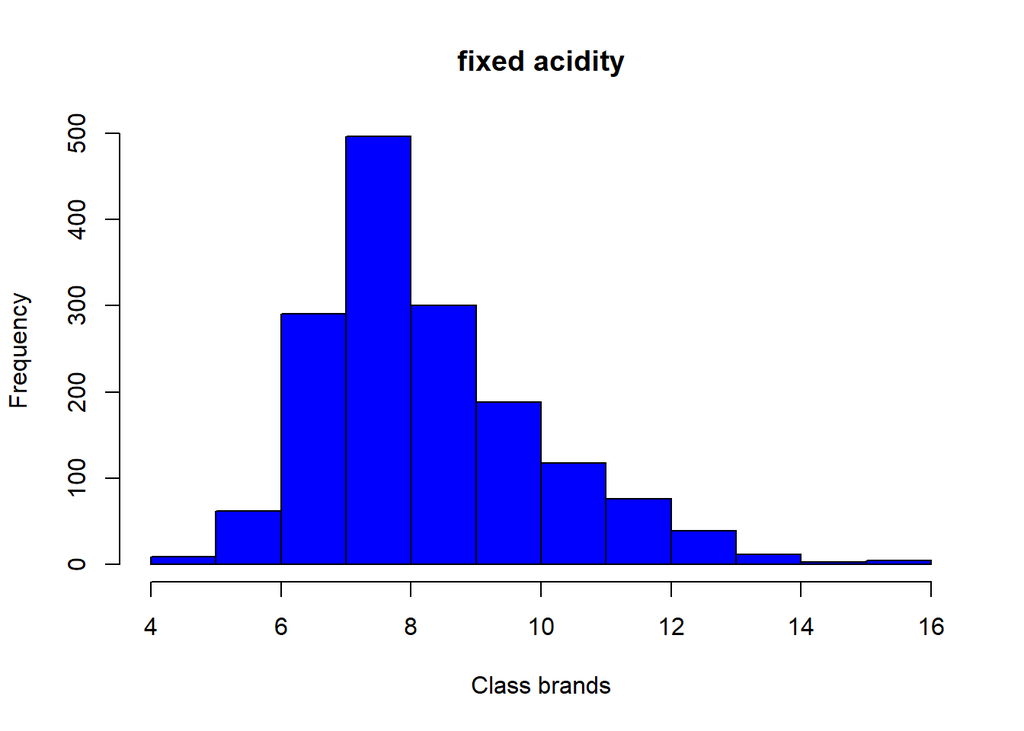

```r
# Histograma de frecuencias absolutas de las variables fisicoquímicas
hist(winequality.red$fixed.acidity, main="fixed acidity", xlab="Class brands", ylab="Frequency", col="blue")
```

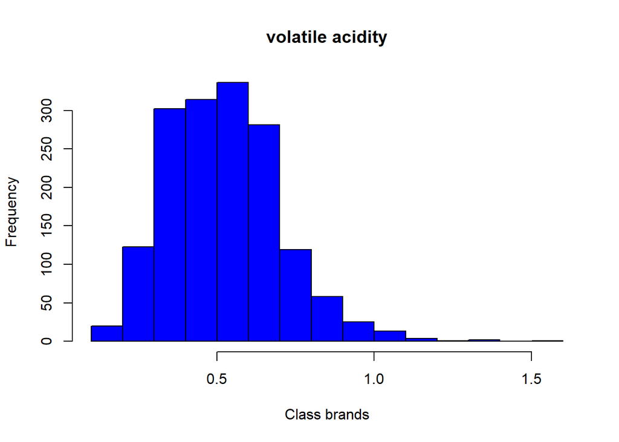

```r
hist(winequality.red$volatile.acidity, main="volatile acidity", xlab="Class brands", ylab="Frequency", col="blue")
```

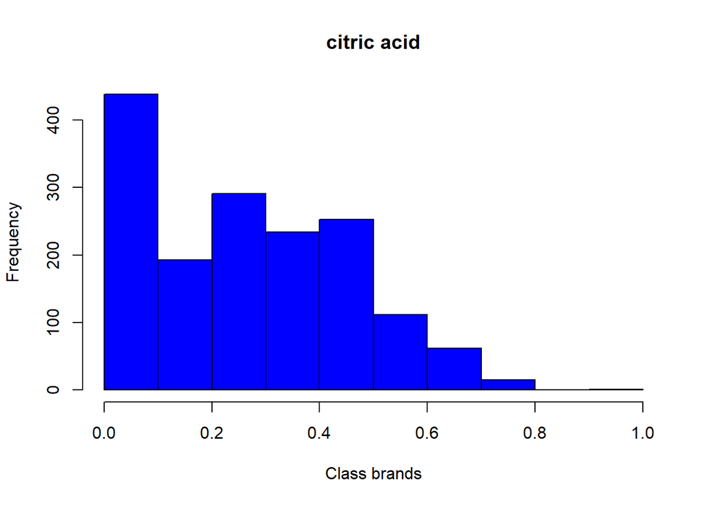

```r
hist(winequality.red$citric.acid, main="citric acid", xlab="Class brands", ylab="Frequency", col="blue")
```

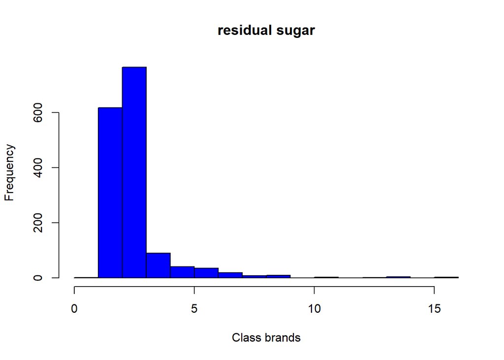

```r
hist(winequality.red$residual.sugar, main="residual sugar", xlab="Class brands", ylab="Frequency", col="blue")
```

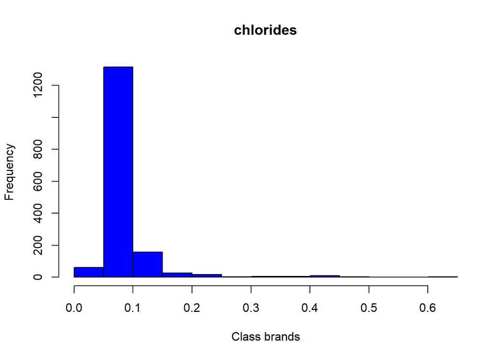

```r
hist(winequality.red$chlorides, main="chlorides", xlab="Class brands", ylab="Frequency", col="blue")
```

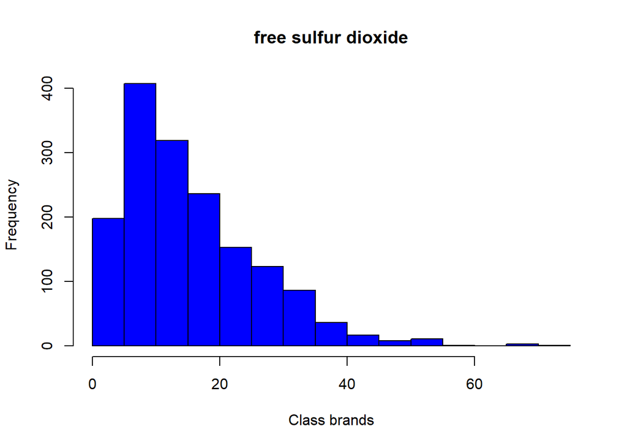

```r
hist(winequality.red$free.sulfur.dioxide, main="free sulfur dioxide", xlab="Class brands", ylab="Frequency", col="blue")
```

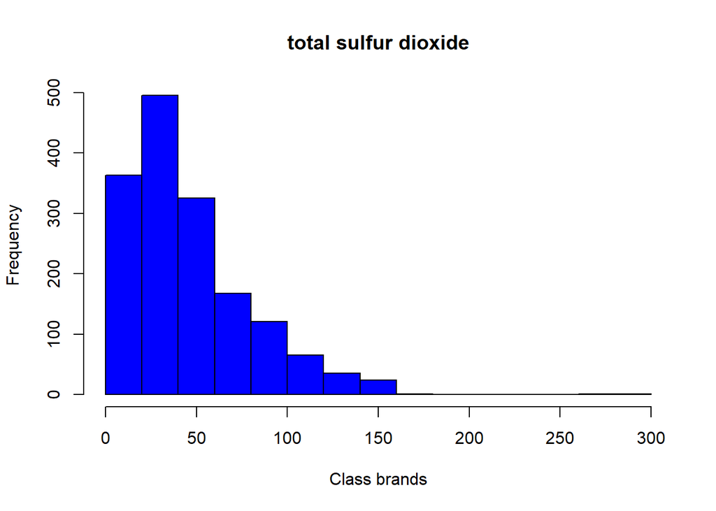

```r
hist(winequality.red$total.sulfur.dioxide, main="total sulfur dioxide", xlab="Class brands", ylab="Frequency", col="blue")
```

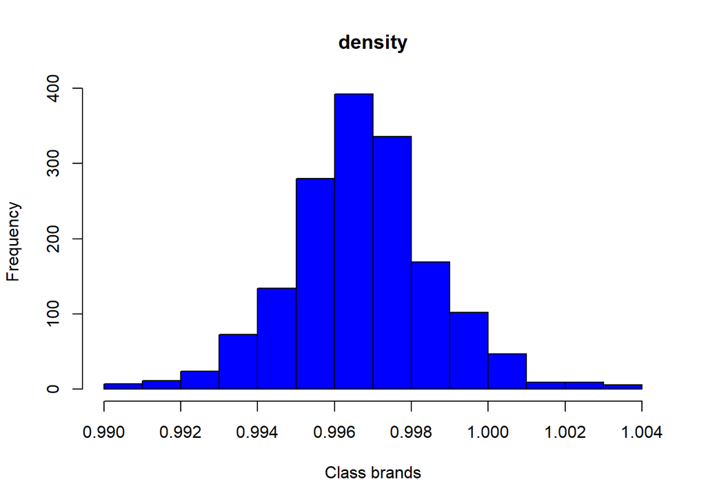

```r
hist(winequality.red$density, main="density", xlab="Class brands", ylab="Frequency", col="blue")
```

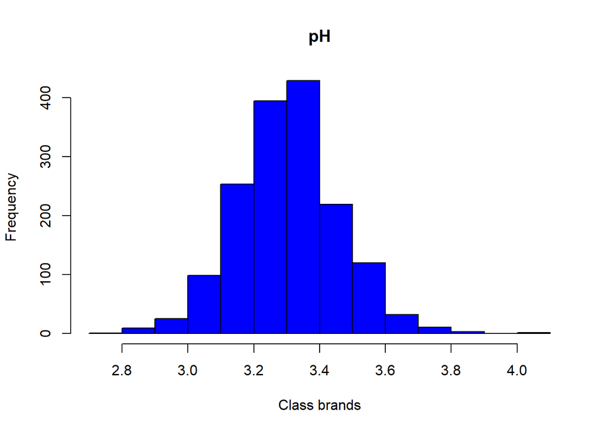

```r
hist(winequality.red$pH, main="pH", xlab="Class brands", ylab="Frequency", col="blue")
```

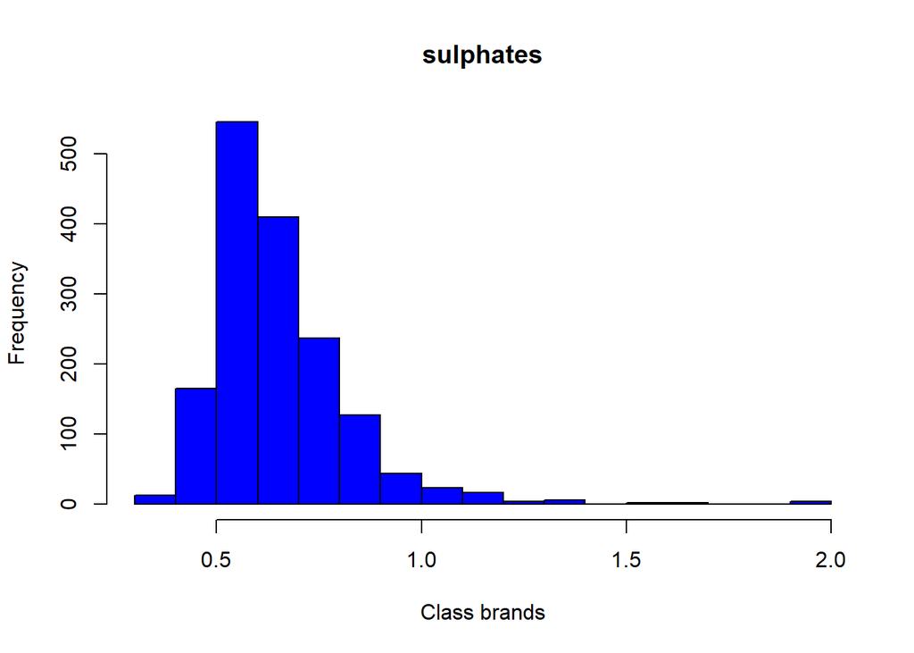

```r
hist(winequality.red$sulphates, main="sulphates", xlab="Class brands", ylab="Frequency", col="blue")
```

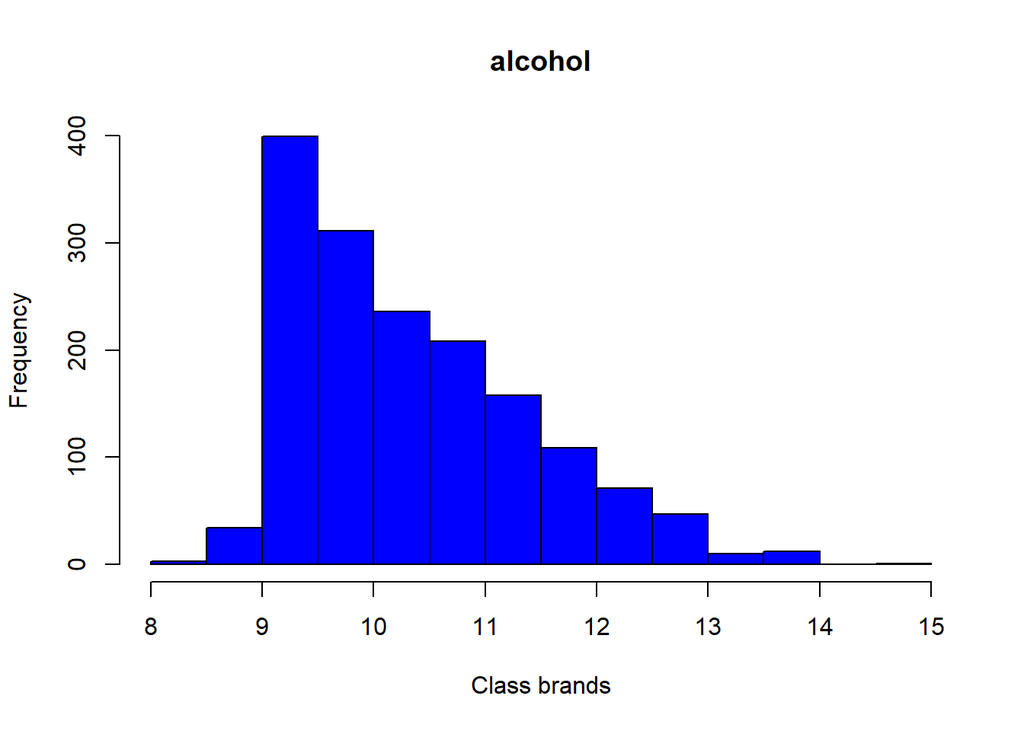

```r
hist(winequality.red$alcohol, main="alcohol", xlab="Class brands", ylab="Frequency", col="blue")
```

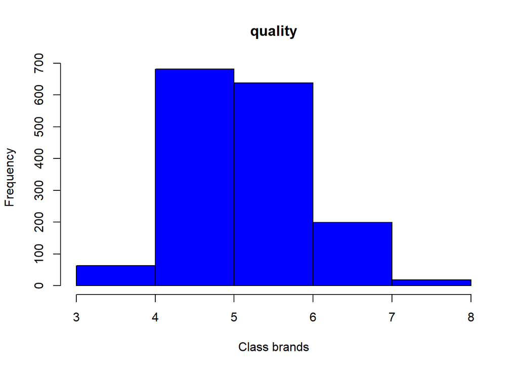

```r
hist(winequality.red$quality, main="quality", xlab="Class brands", ylab="Frequency", col="blue", breaks = 5)
```

## 2.1 Integración y selección de los datos de interés

En esta sección, eliminamos columnas innecesarias o redundantes y fijamos el número de cifras decimales que deben contemplar. Se establece la columna “quality” de tipo numérico para facilitar cálculos y resultados posteriores.

```r
# Eliminación de datos de columnas redundantes
winequality.red <- winequality.red[, -(6:6)]
# Unimos las dos columnas de acidez (fija y volátil) en una sola columna
winequality.red$fixed.acidity<-winequality.red$fixed.acidity + winequality.red$volatile.acidity
winequality.red$fixed.acidity<-round(winequality.red$fixed.acidity,2)
colnames(winequality.red)[colnames(winequality.red)=="fixed.acidity"] <- "acidity"
# Ahora que ya disponemos de la acidez total, eliminamos la columna "volatile.acidity":
winequality.red <- winequality.red[, -(2:2)]
head(winequality.red)
```

```
##   acidity citric.acid residual.sugar chlorides total.sulfur.dioxide
## 1    8.10        0.00            1.9     0.076                   34
## 2    8.68        0.00            2.6     0.098                   67
## 3    8.56        0.04            2.3     0.092                   54
## 4   11.48        0.56            1.9     0.075                   60
## 5    8.10        0.00            1.9     0.076                   34
## 6    8.06        0.00            1.8     0.075                   40
##   density   pH sulphates alcohol quality
## 1  0.9978 3.51      0.56     9.4       5
## 2  0.9968 3.20      0.68     9.8       5
## 3  0.9970 3.26      0.65     9.8       5
## 4  0.9980 3.16      0.58     9.8       6
## 5  0.9978 3.51      0.56     9.4       5
## 6  0.9978 3.51      0.56     9.4       5
```

```r
# Establecemos el número de cifras decimales en las columnas "acidity", "citric.acid" "chlorides" y "density"
winequality.red$acidity<-round(winequality.red$acidity, 2)
winequality.red$citric.acid<-round(winequality.red$citric.acid, 2)
winequality.red$chlorides<-round(winequality.red$chlorides, 3)
winequality.red$density<-round(winequality.red$density, 4)
# Convertimos la columna "quality" a tipo "numeric":
winequality.red$quality<-as.numeric(winequality.red$quality)
class(winequality.red$quality)
```

```
## [1] "numeric"
```

## 2.2 Detección de ceros y elementos vacíos por campo

En esta sección, se lleva a cabo la detección de ceros y elementos vacíos por campo

```r
# Número de valores desconocidos por campo
sapply(winequality.red, function(x) sum(is.na(x)))
```

```
##              acidity          citric.acid       residual.sugar
##                    0                    0                    0
##            chlorides total.sulfur.dioxide              density
##                    0                    0                    0
##                   pH            sulphates              alcohol
##                    0                    0                    0
##              quality
##                    0
```

## 2.3 Valores extremos

Identificamos outliers de cada variable fisicoquímica mediante diagramas de caja y usando la función boxplots.stats() de R.

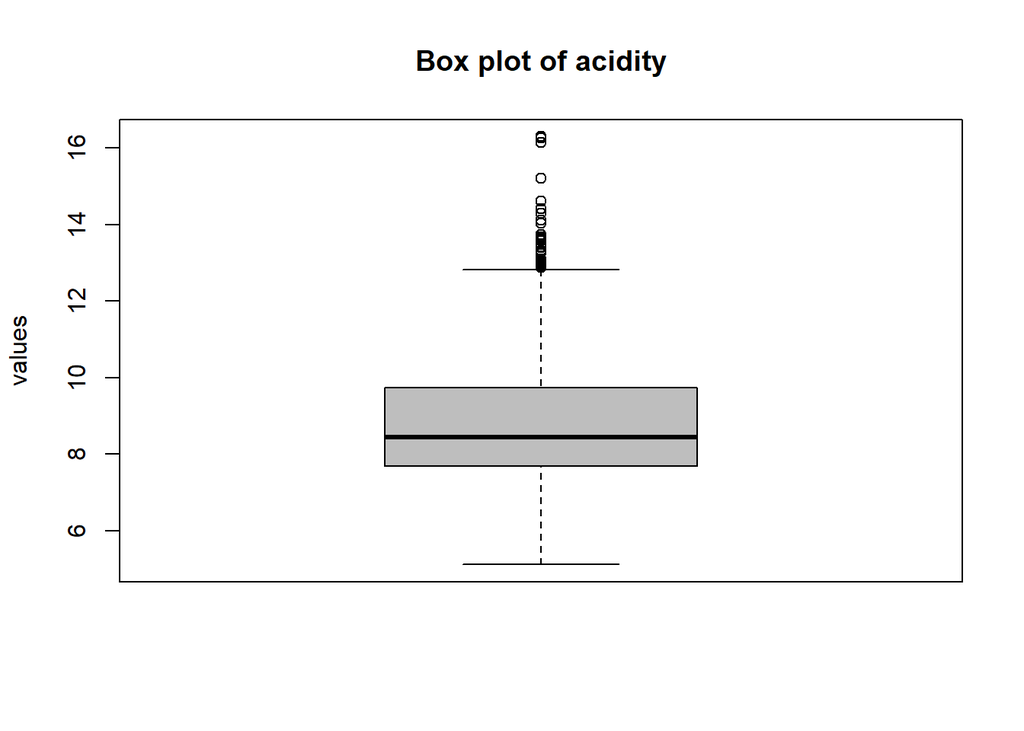

```r
boxplot(winequality.red$acidity,main="Box plot of acidity", col="gray",ylab="values")
```

```r
boxplot.stats(winequality.red$acidity)$out
```

```
##  [1] 13.10 13.10 15.21 15.21 13.06 13.64 13.67 12.89 14.29 14.03 12.98
## [12] 12.96 13.42 13.42 14.41 14.11 14.11 13.30 12.96 13.64 12.91 16.29
## [23] 12.88 13.32 12.87 13.59 13.10 13.25 14.61 16.14 16.14 16.25 13.47
## [34] 13.30 13.47 13.30 13.29 13.66 13.66 13.58 16.26 13.73 13.40 13.01
## [45] 12.99
```

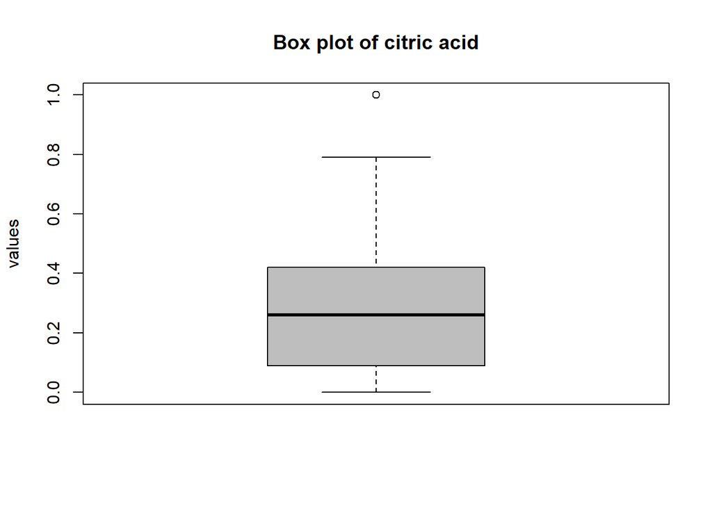

```r
boxplot(winequality.red$citric.acid,main="Box plot of citric acid", col="gray",ylab="values")
```

```r
boxplot.stats(winequality.red$citric.acid)$out
```

```
## [1] 1
```

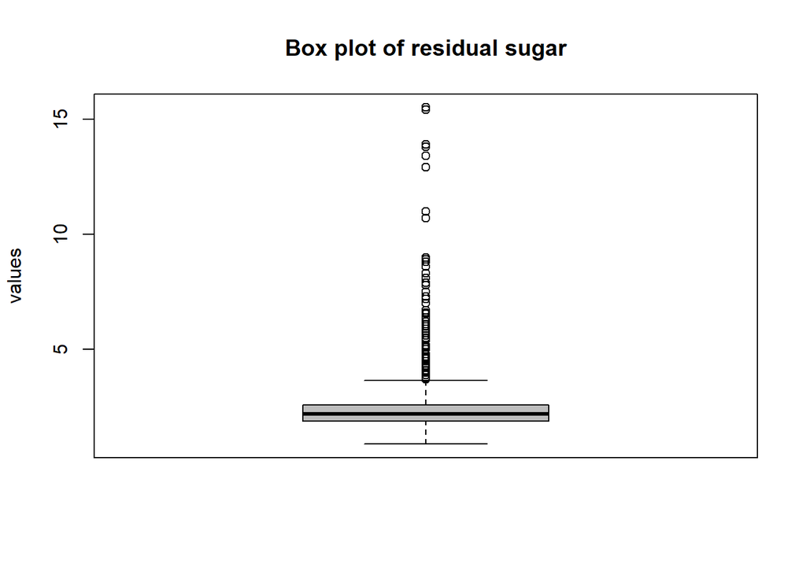

```r
boxplot(winequality.red$residual.sugar,main="Box plot of residual sugar", col="gray",ylab="values")
```

```r
boxplot.stats(winequality.red$residual.sugar)$out
```

```
##   [1]  6.10  6.10  3.80  3.90  4.40 10.70  5.50  5.90  5.90  3.80  5.10
##  [12]  4.65  4.65  5.50  5.50  5.50  5.50  7.30  7.20  3.80  5.60  4.00
##  [23]  4.00  4.00  4.00  7.00  4.00  4.00  6.40  5.60  5.60 11.00 11.00
##  [34]  4.50  4.80  5.80  5.80  3.80  4.40  6.20  4.20  7.90  7.90  3.70
##  [45]  4.50  6.70  6.60  3.70  5.20 15.50  4.10  8.30  6.55  6.55  4.60
##  [56]  6.10  4.30  5.80  5.15  6.30  4.20  4.20  4.60  4.20  4.60  4.30
##  [67]  4.30  7.90  4.60  5.10  5.60  5.60  6.00  8.60  7.50  4.40  4.25
##  [78]  6.00  3.90  4.20  4.00  4.00  4.00  6.60  6.00  6.00  3.80  9.00
##  [89]  4.60  8.80  8.80  5.00  3.80  4.10  5.90  4.10  6.20  8.90  4.00
## [100]  3.90  4.00  8.10  8.10  6.40  6.40  8.30  8.30  4.70  5.50  5.50
## [111]  4.30  5.50  3.70  6.20  5.60  7.80  4.60  5.80  4.10 12.90  4.30
## [122] 13.40  4.80  6.30  4.50  4.50  4.30  4.30  3.90  3.80  5.40  3.80
## [133]  6.10  3.90  5.10  5.10  3.90 15.40 15.40  4.80  5.20  5.20  3.75
## [144] 13.80 13.80  5.70  4.30  4.10  4.10  4.40  3.70  6.70 13.90  5.10
## [155]  7.80
```

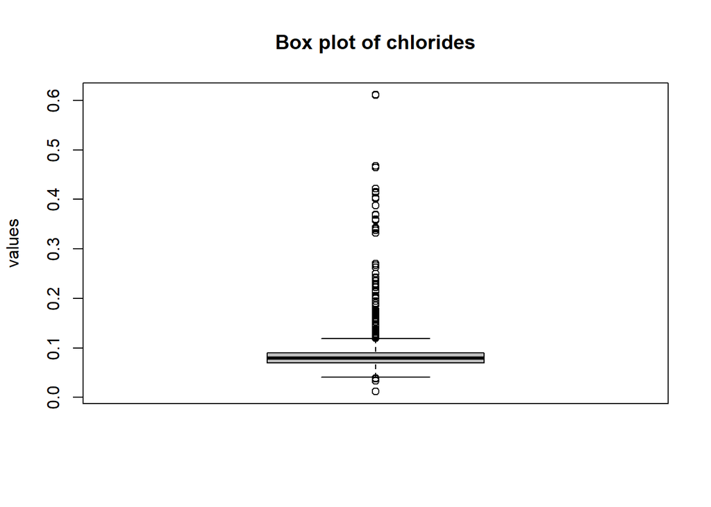

```r
boxplot(winequality.red$chlorides,main="Box plot of chlorides", col="gray",ylab="values")
```

```r
boxplot.stats(winequality.red$chlorides)$out
```

```
##   [1] 0.176 0.170 0.368 0.341 0.172 0.332 0.464 0.401 0.467 0.122 0.178
##  [12] 0.146 0.236 0.610 0.360 0.270 0.039 0.337 0.263 0.611 0.358 0.343
##  [23] 0.186 0.213 0.214 0.121 0.122 0.122 0.128 0.120 0.159 0.124 0.122
##  [34] 0.122 0.174 0.121 0.127 0.413 0.152 0.152 0.125 0.122 0.200 0.171
##  [45] 0.226 0.226 0.250 0.148 0.122 0.124 0.124 0.143 0.222 0.039 0.157
##  [56] 0.422 0.034 0.387 0.415 0.157 0.157 0.243 0.241 0.190 0.132 0.126
##  [67] 0.038 0.165 0.145 0.147 0.012 0.012 0.039 0.194 0.132 0.161 0.120
##  [78] 0.120 0.123 0.123 0.414 0.216 0.171 0.178 0.369 0.166 0.166 0.136
##  [89] 0.132 0.132 0.123 0.123 0.123 0.403 0.137 0.414 0.166 0.168 0.415
## [100] 0.153 0.415 0.267 0.123 0.214 0.214 0.169 0.205 0.205 0.039 0.235
## [111] 0.230 0.038
```

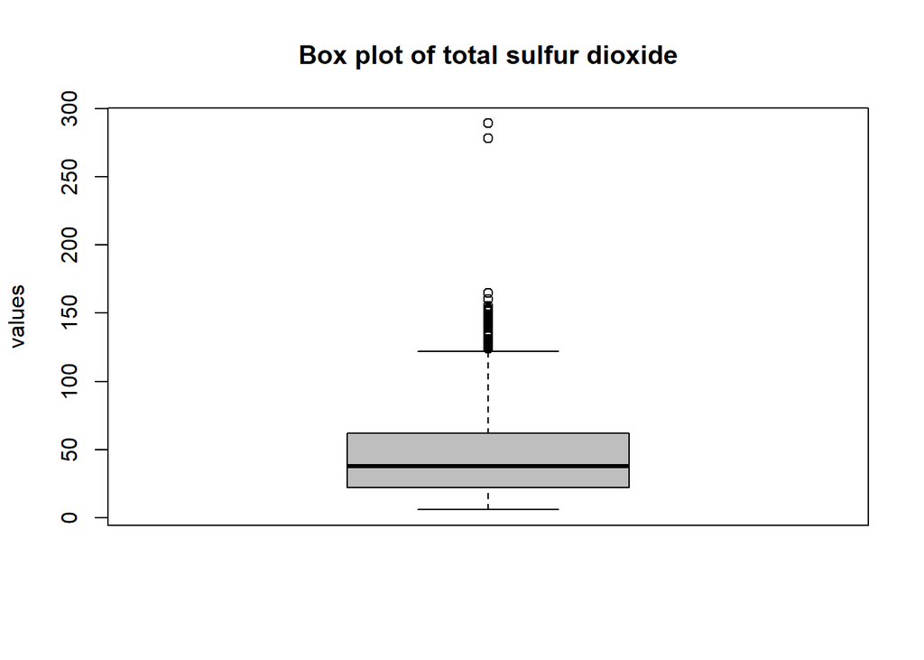

```r
boxplot(winequality.red$total.sulfur.dioxide,main="Box plot of total sulfur dioxide", col="gray",ylab="values")
```

```r
boxplot.stats(winequality.red$total.sulfur.dioxide)$out
```

```
##  [1] 145 148 136 125 140 136 133 153 134 141 129 128 129 128 143 144 127
## [18] 126 145 144 135 165 124 124 134 124 129 151 133 142 149 147 145 148
## [35] 155 151 152 125 127 139 143 144 130 278 289 135 160 141 141 133 147
## [52] 147 131 131 131
```

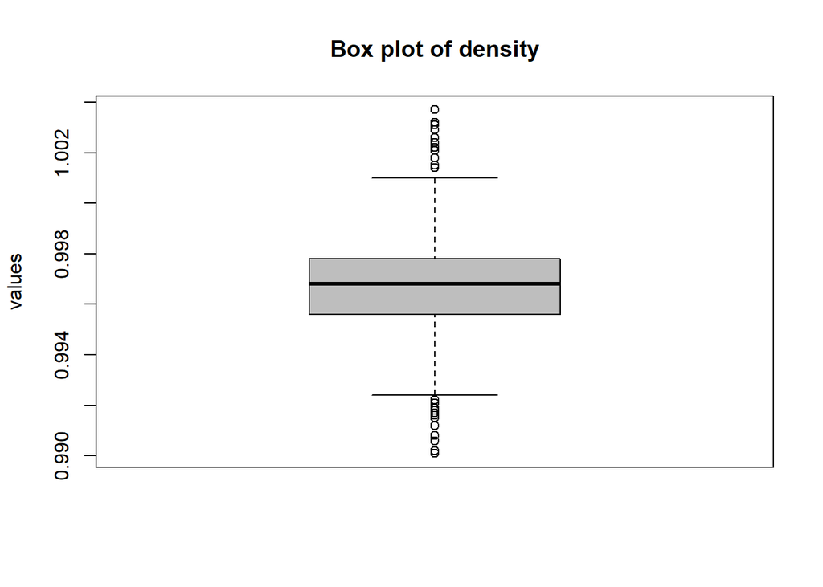

```r
boxplot(winequality.red$density,main="Box plot of density", col="gray",ylab="values")
```

```r
boxplot.stats(winequality.red$density)$out
```

```
##  [1] 0.9916 0.9916 1.0014 1.0015 1.0015 1.0018 0.9912 1.0022 1.0022 1.0014
## [11] 1.0014 1.0014 1.0014 1.0032 1.0026 1.0014 1.0031 1.0031 1.0031 1.0021
## [21] 1.0021 0.9917 0.9922 1.0026 0.9921 0.9915 0.9906 0.9906 1.0029 0.9916
## [31] 0.9901 0.9901 0.9902 0.9922 0.9915 0.9916 0.9908 0.9908 0.9919 1.0037
## [41] 1.0037 1.0024 0.9918 1.0024 0.9918
```

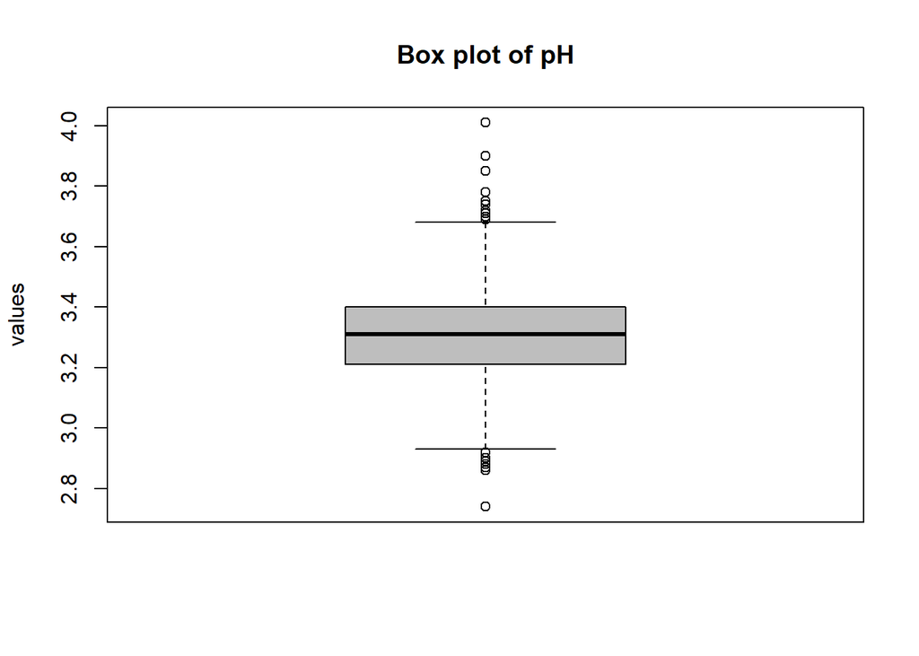

```r
boxplot(winequality.red$pH,main="Box plot of pH", col="gray",ylab="values")
```

```r
boxplot.stats(winequality.red$pH)$out
```

```
##  [1] 3.90 3.75 3.85 2.74 3.69 3.69 2.88 2.86 3.74 2.92 2.92 2.92 3.72 2.87
## [15] 2.89 2.89 2.92 3.90 3.71 3.69 3.69 3.71 3.71 2.89 2.89 3.78 3.70 3.78
## [29] 4.01 2.90 4.01 3.71 2.88 3.72 3.72
```

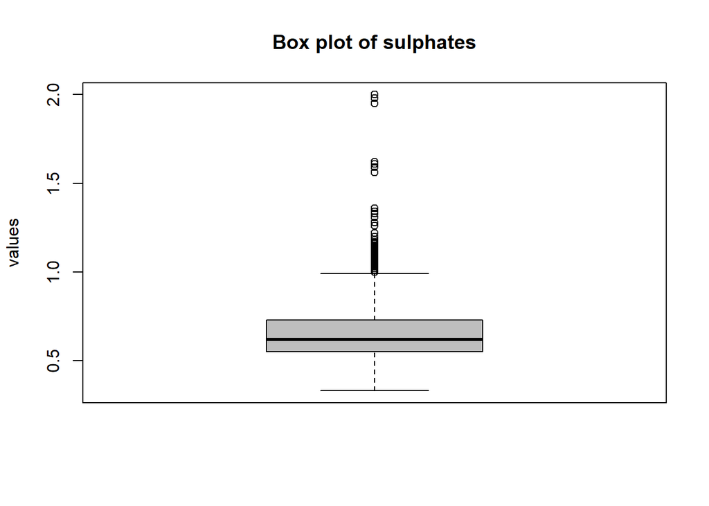

```r
boxplot(winequality.red$sulphates,main="Box plot of sulphates", col="gray",ylab="values")
```

```r
boxplot.stats(winequality.red$sulphates)$out
```

```
##  [1] 1.56 1.28 1.08 1.20 1.12 1.28 1.14 1.95 1.22 1.95 1.98 1.31 2.00 1.08
## [15] 1.59 1.02 1.03 1.61 1.09 1.26 1.08 1.00 1.36 1.18 1.13 1.04 1.11 1.13
## [29] 1.07 1.06 1.06 1.05 1.06 1.04 1.05 1.02 1.14 1.02 1.36 1.36 1.05 1.17
## [43] 1.62 1.06 1.18 1.07 1.34 1.16 1.10 1.15 1.17 1.17 1.33 1.18 1.17 1.03
## [57] 1.17 1.10 1.01
```

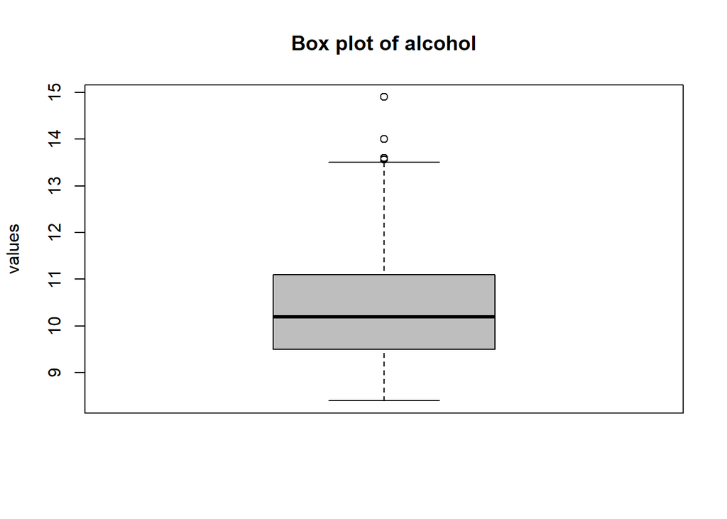

```r
boxplot(winequality.red$alcohol,main="Box plot of alcohol", col="gray",ylab="values")
```

```r
boxplot.stats(winequality.red$alcohol)$out
```

```
##  [1] 14.00000 14.00000 14.00000 14.00000 14.90000 14.00000 13.60000
##  [8] 13.60000 13.60000 14.00000 14.00000 13.56667 13.60000
```

```r
# Eliminamos valores outliers de cada una de las variables fisicoquímicas.

outliers.acidity <- boxplot(winequality.red$acidity, plot=FALSE)$out
winequality.red <- winequality.red[-which(winequality.red$acidity %in% outliers.acidity),]

outliers.citric.acid <- boxplot(winequality.red$citric.acid, plot=FALSE)$out
winequality.red <- winequality.red[-which(winequality.red$citric.acid %in% outliers.citric.acid),]

outliers.residual.sugar <- boxplot(winequality.red$residual.sugar, plot=FALSE)$out
winequality.red <- winequality.red[-which(winequality.red$residual.sugar %in% outliers.residual.sugar),]

outliers.chlorides <- boxplot(winequality.red$chlorides, plot=FALSE)$out
winequality.red <- winequality.red[-which(winequality.red$chlorides %in% outliers.chlorides),]

outliers.total.sulfur.dioxide <- boxplot(winequality.red$total.sulfur.dioxide, plot=FALSE)$out
winequality.red <- winequality.red[-which(winequality.red$total.sulfur.dioxide %in% outliers.total.sulfur.dioxide),]

outliers.density <- boxplot(winequality.red$density, plot=FALSE)$out
winequality.red <- winequality.red[-which(winequality.red$density %in% outliers.density),]

outliers.pH <- boxplot(winequality.red$pH, plot=FALSE)$out
winequality.red <- winequality.red[-which(winequality.red$pH %in% outliers.pH),]

outliers.sulphates <- boxplot(winequality.red$sulphates, plot=FALSE)$out
winequality.red <- winequality.red[-which(winequality.red$sulphates %in% outliers.sulphates),]

outliers.alcohol <- boxplot(winequality.red$alcohol, plot=FALSE)$out
winequality.red <- winequality.red[-which(winequality.red$alcohol %in% outliers.alcohol),]
```

```r
# Número de columnas y registros o filas del nuevo dataset
ncol(winequality.red)
```

```
## [1] 10
```

```r
nrow(winequality.red)
```

```
## [1] 1182
```

## 2.4 Exportación de los datos preprocesados

Una vez limpiados los datos, los guardamos en un fichero llamado winequality-red_data_clean.csv

```r
write.csv(winequality.red, "C:/Users/Antonio/Desktop/UOC/Tipologýa y ciclo de vida de los datos/PRAC2/winequality-red_data_clean.csv")
```

# 3 Análisis de resultados

## 3.1 Selección de los grupos de datos que se quieren comparar

Establecemos grupos dentro del conjunto de datos para posteriores análisis y comparaciones.

```r
# Agrupación por valores de densidad
low.density <- winequality.red[winequality.red$density <= mean(winequality.red$density),]
high.density <- winequality.red[winequality.red$density > mean(winequality.red$density),]

# Agrupación por porcentaje de alcohol en vino
low.alcohol.percentage<- winequality.red[winequality.red$alcohol <= 11.5,]
high.alcohol.percentage <- winequality.red[winequality.red$alcohol > 11.5,]

# Agrupación por cantidad de sal presente en el vino
low.clhorides <- winequality.red[winequality.red$chlorides <= mean(winequality.red$chlorides),]
high.clhorides <- winequality.red[winequality.red$chlorides > mean(winequality.red$chlorides),]
```

## 3.2 Pruebas de normalidad y homogeneidad de la varianza

Pruebas de normalidad de Anderson-Darling

```r
library(nortest)
alpha = 0.05
col.names = colnames(winequality.red)
for (i in 1:ncol(winequality.red)) {
if (i == 1) cat("Listado de variables fisicoquímicas que no siguen una distribución normal:\n")
if (is.integer(winequality.red[,i]) | is.numeric(winequality.red[,i])) {
p_val = ad.test(winequality.red[,i])$p.value
if (p_val < alpha) {
cat(col.names[i])
# Format output
if (i < ncol(winequality.red) - 1) cat(", ")
if (i %% 3 == 0) cat("\n")
}
}
}
```

```
## Listado de variables fisicoquímicas que no siguen una distribución normal:
## acidity, citric.acid, residual.sugar,
## chlorides, total.sulfur.dioxide, density,
## pH, sulphates, alcohol
## quality
```

Test de normalidad Shapiro-Wilk y gráficos Q-Q

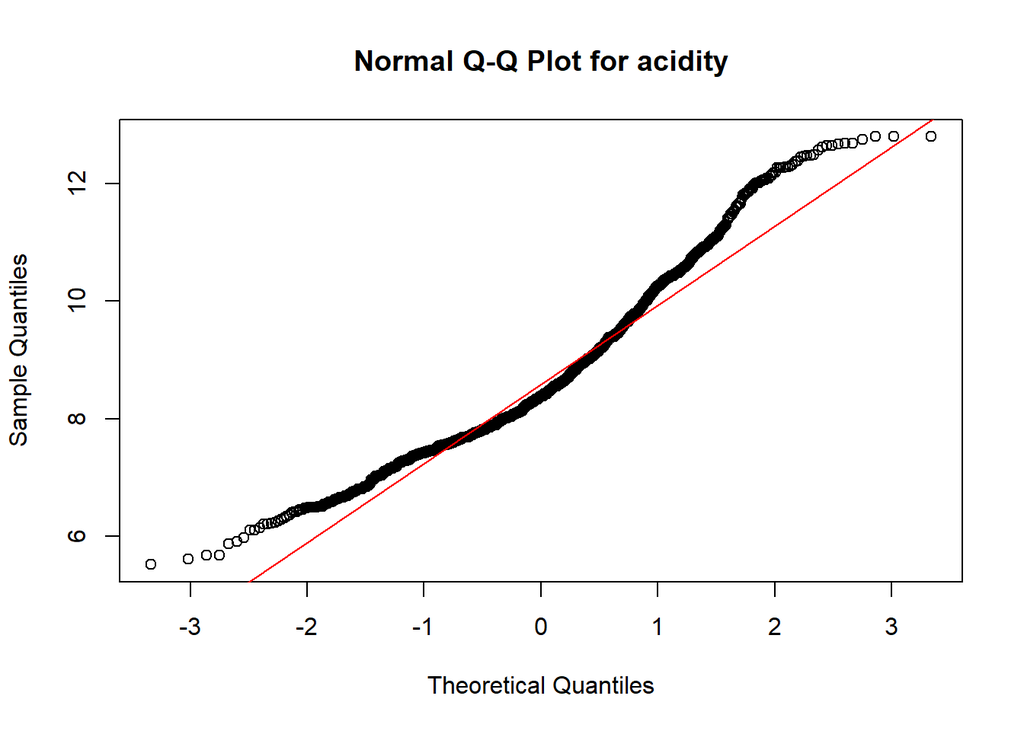

```r
qqnorm(winequality.red$acidity, main = "Normal Q-Q Plot for acidity")
qqline(winequality.red$acidity, col = "red")
```

```r
shapiro.test(winequality.red$acidity)
```

```
##
##  Shapiro-Wilk normality test
##
## data:  winequality.red$acidity
## W = 0.95654, p-value < 2.2e-16
```

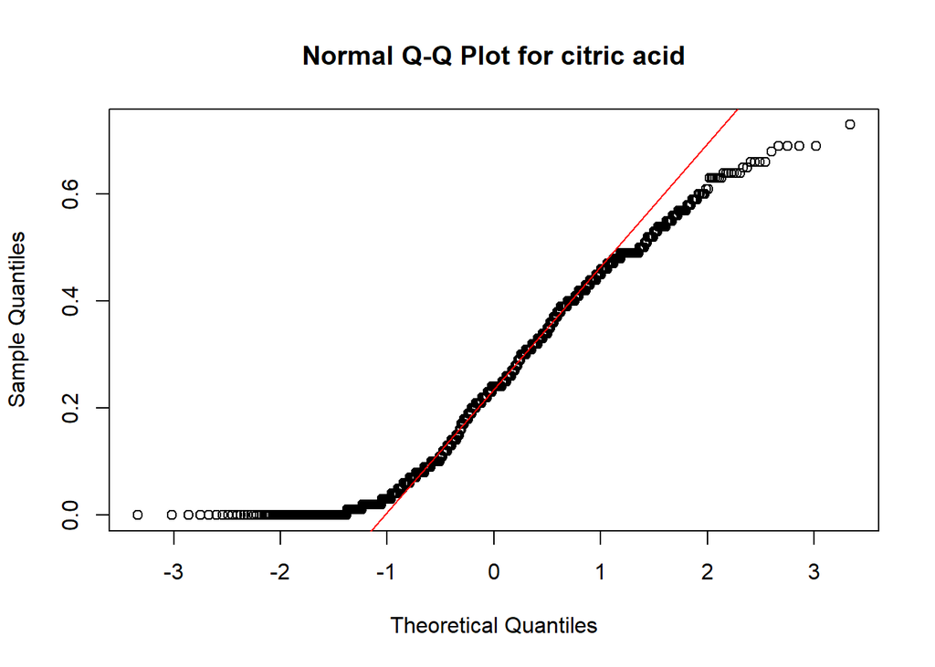

```r
qqnorm(winequality.red$citric.acid, main = "Normal Q-Q Plot for citric acid")
qqline(winequality.red$citric.acid, col = "red")
```

```r
shapiro.test(winequality.red$citric.acid)
```

```
##
##  Shapiro-Wilk normality test
##
## data:  winequality.red$citric.acid
## W = 0.94951, p-value < 2.2e-16
```

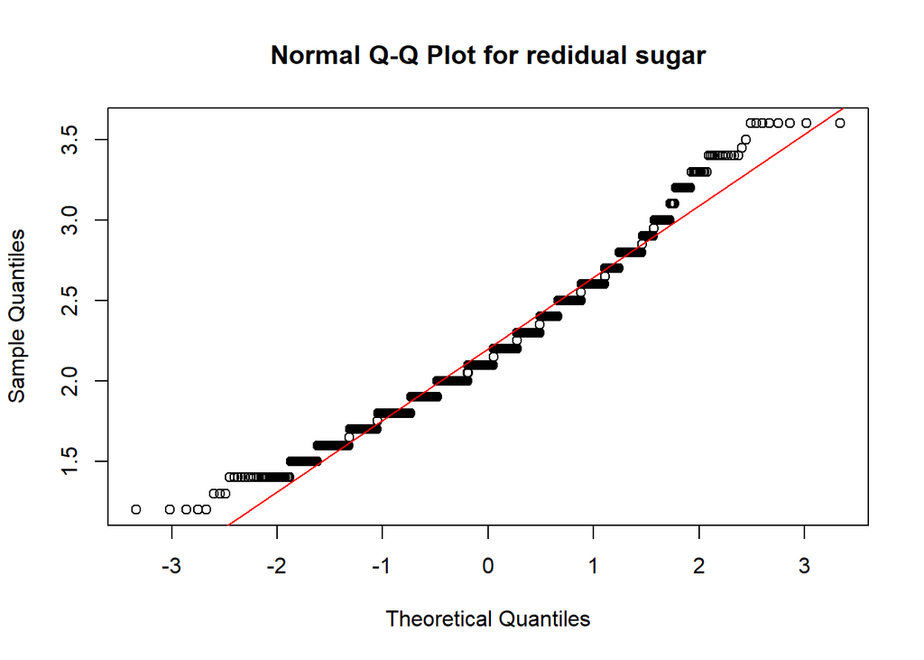

```r
qqnorm(winequality.red$residual.sugar, main = "Normal Q-Q Plot for redidual sugar")
qqline(winequality.red$residual.sugar, col = "red")
```

```r
shapiro.test(winequality.red$residual.sugar)
```

```
##
##  Shapiro-Wilk normality test
##
## data:  winequality.red$residual.sugar
## W = 0.97058, p-value = 9.184e-15
```

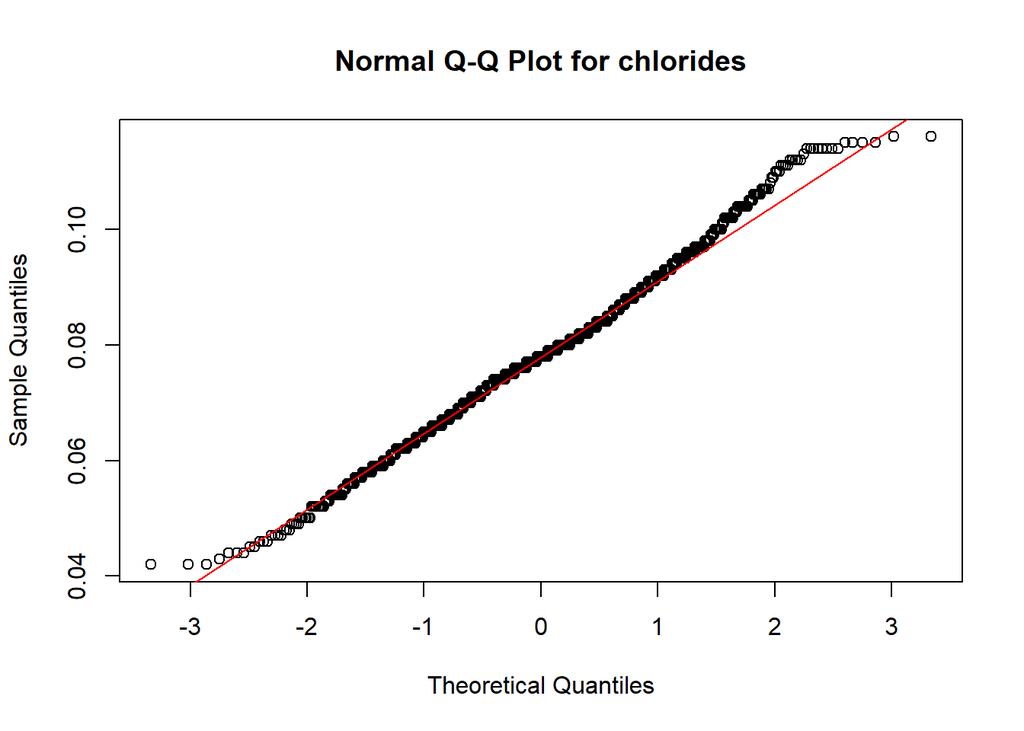

```r
qqnorm(winequality.red$chlorides, main = "Normal Q-Q Plot for chlorides")
qqline(winequality.red$chlorides, col = "red")
```

```r
shapiro.test(winequality.red$chlorides)
```

```
##
##  Shapiro-Wilk normality test
##
## data:  winequality.red$chlorides
## W = 0.99382, p-value = 8.049e-05
```

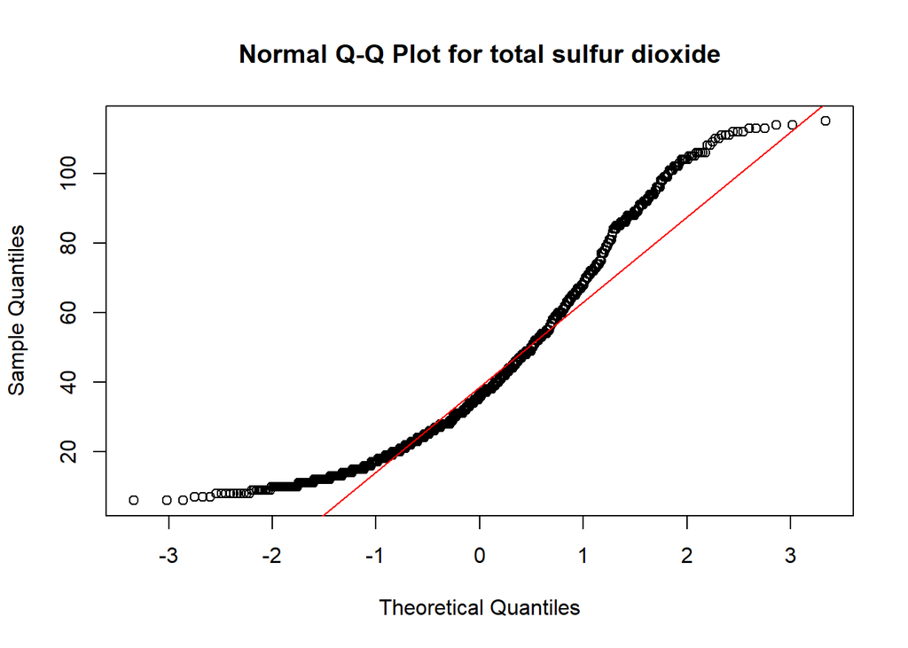

```r
qqnorm(winequality.red$total.sulfur.dioxide, main = "Normal Q-Q Plot for total sulfur dioxide")
qqline(winequality.red$total.sulfur.dioxide, col = "red")
```

```r
shapiro.test(winequality.red$total.sulfur.dioxide)
```

```
##
##  Shapiro-Wilk normality test
##
## data:  winequality.red$total.sulfur.dioxide
## W = 0.92227, p-value < 2.2e-16
```

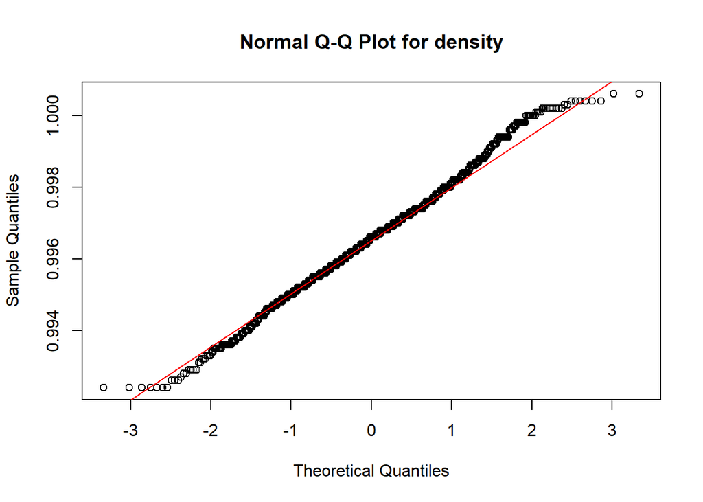

```r
qqnorm(winequality.red$density, main = "Normal Q-Q Plot for density")
qqline(winequality.red$density, col = "red")
```

```r
shapiro.test(winequality.red$density)
```

```
##
##  Shapiro-Wilk normality test
##
## data:  winequality.red$density
## W = 0.99502, p-value = 0.0006067
```

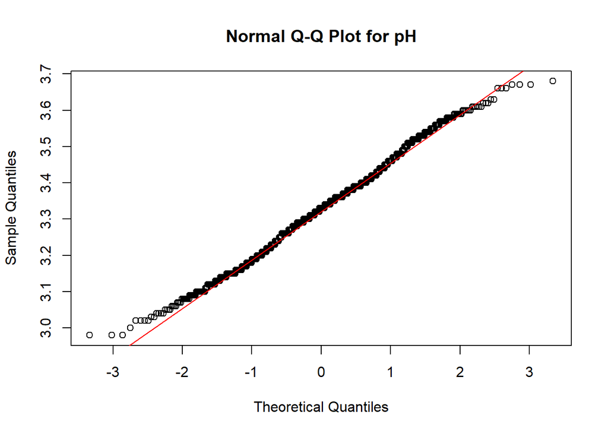

```r
qqnorm(winequality.red$pH, main = "Normal Q-Q Plot for pH")
qqline(winequality.red$pH, col = "red")
```

```r
shapiro.test(winequality.red$pH)
```

```
##
##  Shapiro-Wilk normality test
##
## data:  winequality.red$pH
## W = 0.99516, p-value = 0.0007893
```

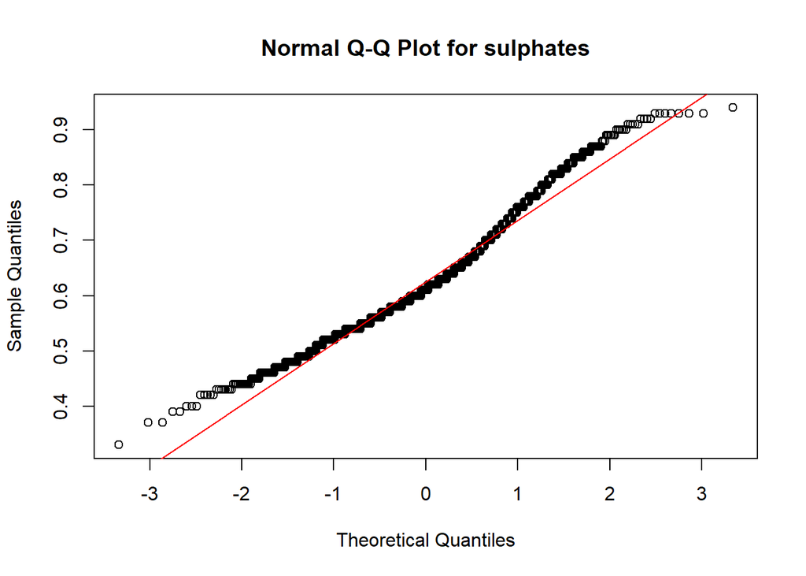

```r
qqnorm(winequality.red$sulphates, main = "Normal Q-Q Plot for sulphates")
qqline(winequality.red$sulphates, col = "red")
```

```r
shapiro.test(winequality.red$sulphates)
```

```
##
##  Shapiro-Wilk normality test
##
## data:  winequality.red$sulphates
## W = 0.9721, p-value = 2.543e-14
```

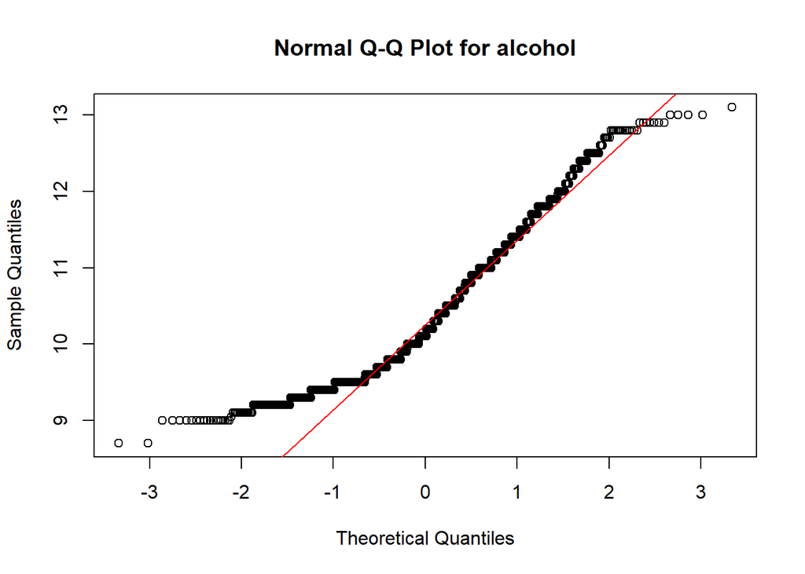

```r
qqnorm(winequality.red$alcohol, main = "Normal Q-Q Plot for alcohol")
qqline(winequality.red$alcohol, col = "red")
```

```r
shapiro.test(winequality.red$alcohol)
```

```
##
##  Shapiro-Wilk normality test
##
## data:  winequality.red$alcohol
## W = 0.93279, p-value < 2.2e-16
```

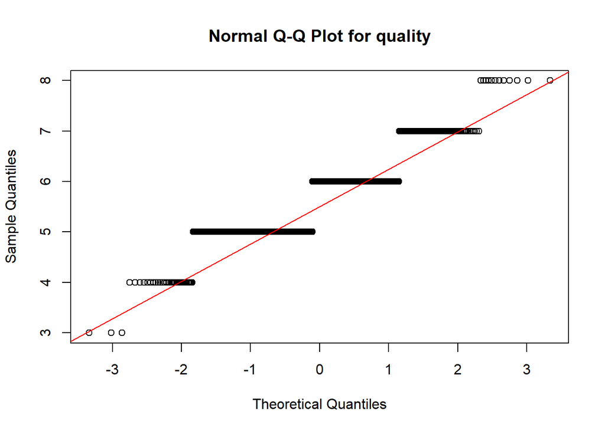

```r
qqnorm(winequality.red$quality, main = "Normal Q-Q Plot for quality")
qqline(winequality.red$quality, col = "red")
```

```r
shapiro.test(winequality.red$quality)
```

```
##
##  Shapiro-Wilk normality test
##
## data:  winequality.red$quality
## W = 0.84742, p-value < 2.2e-16
```

Estudio de la homogeneidad de las varianzas. Test de Fligner-Kileen

```r
fligner.test(quality ~ density, data = winequality.red)
```

```
##
##  Fligner-Killeen test of homogeneity of variances
##
## data:  quality by density
## Fligner-Killeen:med chi-squared = 84.586, df = 77, p-value =
## 0.2593
```

```r
fligner.test(quality ~ alcohol, data = winequality.red)
```

```
##
##  Fligner-Killeen test of homogeneity of variances
##
## data:  quality by alcohol
## Fligner-Killeen:med chi-squared = 72.047, df = 50, p-value =
## 0.02225
```

```r
fligner.test(quality ~ chlorides, data = winequality.red)
```

```
##
##  Fligner-Killeen test of homogeneity of variances
##
## data:  quality by chlorides
## Fligner-Killeen:med chi-squared = 82.893, df = 73, p-value =
## 0.2007
```

# 4 Pruebas estadísticas

## 4.1 Influencia de las variables fisicoquímicas en la calidad de los vinos

```r
corr_matrix <- matrix(nc = 2, nr = 0)
colnames(corr_matrix) <- c("estimate", "p-value")
# Calcular el coeficiente de correlación para cada variable fisicoquimica
# con respecto al campo "quality"
for (i in 1:(ncol(winequality.red) - 1)) {
if (is.integer(winequality.red[,i]) | is.numeric(winequality.red[,i])) {
spearman_test = cor.test(winequality.red[,i],
winequality.red[,length(winequality.red)],
method = "spearman")
corr_coef = spearman_test$estimate
p_val = spearman_test$p.value
# Add row to matrix
pair = matrix(ncol = 2, nrow = 1)
pair[1][1] = corr_coef
pair[2][1] = p_val
corr_matrix <- rbind(corr_matrix, pair)
rownames(corr_matrix)[nrow(corr_matrix)] <- colnames(winequality.red)[i]
}
}
print(corr_matrix)
```

```
##                         estimate      p-value
## acidity               0.06334928 2.941751e-02
## citric.acid           0.22587602 3.864772e-15
## residual.sugar        0.02399919 4.097446e-01
## chlorides            -0.20202975 2.367987e-12
## total.sulfur.dioxide -0.14232988 8.960679e-07
## density              -0.21470668 8.584723e-14
## pH                   -0.06304193 3.021513e-02
## sulphates             0.43853552 9.900814e-57
## alcohol               0.48457880 1.261876e-70
```

## 4.2 Matriz de correlación entre variables

```r
library(PerformanceAnalytics)
# Guardamos datos en un data.frame
acidity<-winequality.red$acidity
citric.acid<-winequality.red$citric.acid
residual.sugar<-winequality.red$residual.sugar
chlorides<-winequality.red$chlorides
total.sulfur.dioxide<-winequality.red$total.sulfur.dioxide
density<-winequality.red$density
pH<-winequality.red$pH
sulphates<-winequality.red$sulphates
alcohol<-winequality.red$alcohol
quality<-winequality.red$quality
data <- data.frame(acidity, citric.acid, residual.sugar, chlorides, total.sulfur.dioxide, density, pH, sulphates, alcohol, quality)
colnames(data) <- c("acidity","citric acid","residual sugar","chlorides","total sulfur dioxide","density", "pH", "sulphates", "alcohol", "quality")
cor(data)
```

```
##                          acidity  citric acid residual sugar   chlorides
## acidity               1.00000000  0.603353709     0.24484897  0.19254182
## citric acid           0.60335371  1.000000000     0.15025882  0.06902013
## residual sugar        0.24484897  0.150258817     1.00000000  0.24054793
## chlorides             0.19254182  0.069020125     0.24054793  1.00000000
## total sulfur dioxide -0.07812217  0.002177295     0.17088644  0.16974256
## density               0.62718180  0.300976996     0.39804848  0.40341417
## pH                   -0.67289768 -0.482954798    -0.05565157 -0.15070000
## sulphates             0.12300305  0.275666484     0.04069258 -0.09583778
## alcohol              -0.05935530  0.146719282     0.10393533 -0.29691699
## quality               0.08447757  0.244631954     0.01784264 -0.18985018
##                      total sulfur dioxide     density           pH
## acidity                      -0.078122174  0.62718180 -0.672897678
## citric acid                   0.002177295  0.30097700 -0.482954798
## residual sugar                0.170886444  0.39804848 -0.055651570
## chlorides                     0.169742556  0.40341417 -0.150699998
## total sulfur dioxide          1.000000000  0.14109698  0.019098399
## density                       0.141096985  1.00000000 -0.223299857
## pH                            0.019098399 -0.22329986  1.000000000
## sulphates                    -0.024142466  0.05816787  0.003591845
## alcohol                      -0.223753777 -0.54100848  0.117723679
## quality                      -0.151868436 -0.21581441 -0.093901964
##                         sulphates    alcohol     quality
## acidity               0.123003050 -0.0593553  0.08447757
## citric acid           0.275666484  0.1467193  0.24463195
## residual sugar        0.040692585  0.1039353  0.01784264
## chlorides            -0.095837782 -0.2969170 -0.18985018
## total sulfur dioxide -0.024142466 -0.2237538 -0.15186844
## density               0.058167875 -0.5410085 -0.21581441
## pH                    0.003591845  0.1177237 -0.09390196
## sulphates             1.000000000  0.2787311  0.43968490
## alcohol               0.278731106  1.0000000  0.49172395
## quality               0.439684896  0.4917240  1.00000000
```

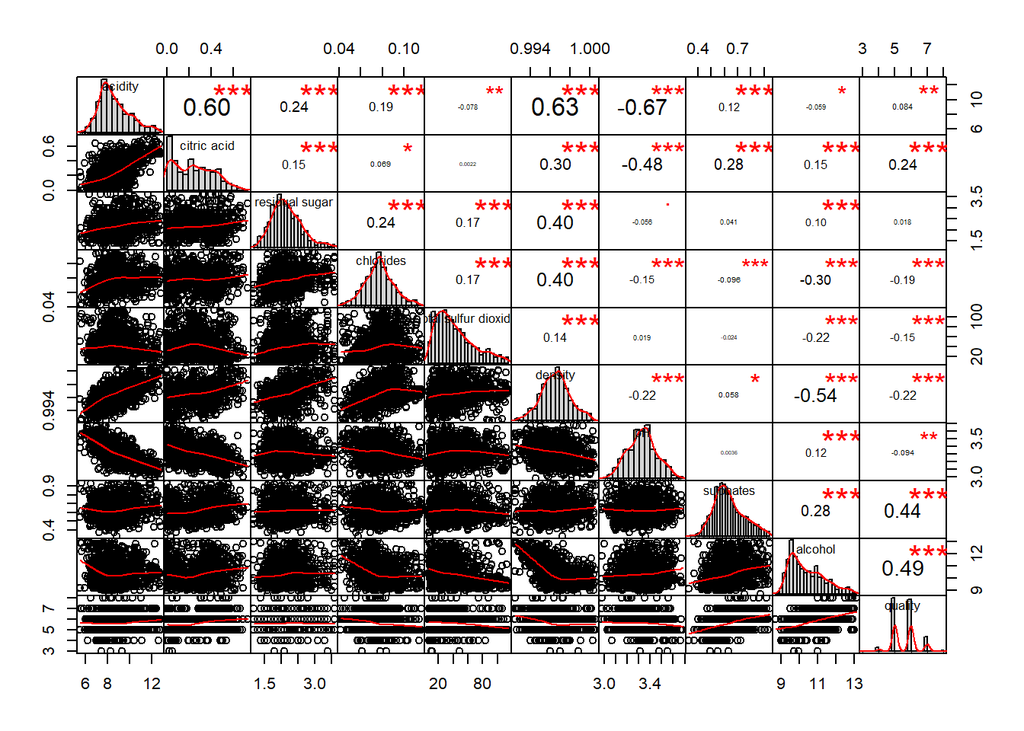

```r
chart.Correlation(data)
```

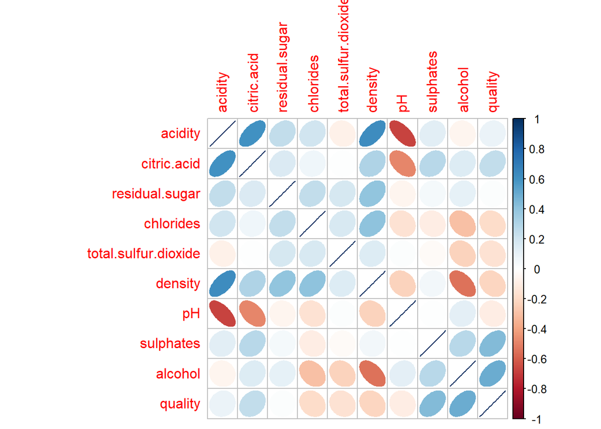

```r
library(corrplot)
M<-cor(winequality.red)
corrplot(M, method = "ellipse")
```

## 4.3 Contrastes de hipótesis

¿La calidad de los vinos con densidad inferior a la media supera la de los vinos con densidad por encima de la media?

```r
low.density.quality <- winequality.red[winequality.red$density <= mean(winequality.red$density),]$quality
high.density.quality <- winequality.red[winequality.red$density > mean(winequality.red$density),]$quality
```

```r
t.test(low.density.quality, high.density.quality, alternative = "less", conf.level = 0.95)
```

```
##
##  Welch Two Sample t-test
##
## data:  low.density.quality and high.density.quality
## t = 5.4571, df = 1155.5, p-value = 1
## alternative hypothesis: true difference in means is less than 0
## 95 percent confidence interval:
##       -Inf 0.3162226
## sample estimates:
## mean of x mean of y
##  5.764605  5.521667
```

¿La calidad de los vinos con menos sal es igual o diferente a la de los vinos más salados?

```r
low.chlorides.quality <- winequality.red[winequality.red$chlorides <= mean(winequality.red$chlorides),]$quality
high.chlorides.quality <- winequality.red[winequality.red$chlorides > mean(winequality.red$chlorides),]$quality
```

```r
t.test(low.chlorides.quality, high.chlorides.quality, alternative = "two.sided", conf.level = 0.95)
```

```
##
##  Welch Two Sample t-test
##
## data:  low.chlorides.quality and high.chlorides.quality
## t = 5.5282, df = 1178.3, p-value = 3.981e-08
## alternative hypothesis: true difference in means is not equal to 0
## 95 percent confidence interval:
##  0.1576308 0.3310735
## sample estimates:
## mean of x mean of y
##  5.757674  5.513321
```

## 4.4 Modelo de regresión lineal

Modelo de regresión multilineal para predecir la calidad

```r
# Regresores cuantitativos más influyentes en la calidad de los vinos
alcohol<-winequality.red$alcohol
sulphates<-winequality.red$sulphates
citric.acid<-winequality.red$citric.acid
density<-winequality.red$density
chlorides<-winequality.red$chlorides
total.sulfur.dioxide<-winequality.red$total.sulfur.dioxide
# Variable que se quiere predecir
quality<-winequality.red$quality
# Modelos de regresión lineal
modelo1 <- lm(quality ~ alcohol + sulphates + citric.acid, data = winequality.red)
modelo2 <- lm(quality ~ alcohol + sulphates + citric.acid + chlorides, data = winequality.red)
modelo3 <- lm(quality ~ alcohol + sulphates + citric.acid + chlorides + density, data = winequality.red)
modelo4 <- lm(quality ~ alcohol + sulphates + citric.acid + density + total.sulfur.dioxide, data = winequality.red)
```

```r
# Tabla con los coeficientes de determinación de cada modelo
tabla.coeficientes <- matrix(c(1, summary(modelo1)$r.squared,
2, summary(modelo2)$r.squared,
3, summary(modelo3)$r.squared,
4, summary(modelo4)$r.squared),
ncol = 2, byrow = TRUE)
colnames(tabla.coeficientes) <- c("Modelo", "R^2")
tabla.coeficientes
```

```
##      Modelo       R^2
## [1,]      1 0.3510071
## [2,]      2 0.3539755
## [3,]      3 0.3572902
## [4,]      4 0.3594511
```

```r
summary(modelo4)
```

```
##
## Call:
## lm(formula = quality ~ alcohol + sulphates + citric.acid + density +
##     total.sulfur.dioxide, data = winequality.red)
##
## Residuals:
##     Min      1Q  Median      3Q     Max
## -2.4797 -0.3792 -0.0628  0.4683  1.9680
##
## Coefficients:
##                        Estimate Std. Error t value Pr(>|t|)
## (Intercept)           4.805e+01  1.545e+01   3.109  0.00192 **
## alcohol               2.543e-01  2.564e-02   9.919  < 2e-16 ***
## sulphates             2.154e+00  1.731e-01  12.443  < 2e-16 ***
## citric.acid           5.990e-01  1.150e-01   5.207 2.26e-07 ***
## density              -4.664e+01  1.537e+01  -3.034  0.00247 **
## total.sulfur.dioxide -1.831e-03  7.327e-04  -2.499  0.01258 *
## ---
## Signif. codes:  0 '***' 0.001 '**' 0.01 '*' 0.05 '.' 0.1 ' ' 1
##
## Residual standard error: 0.6201 on 1176 degrees of freedom
## Multiple R-squared:  0.3595, Adjusted R-squared:  0.3567
## F-statistic:   132 on 5 and 1176 DF,  p-value: < 2.2e-16
```

Predicción de la calidad con el modelo de regresión lineal

```r
newdata <- data.frame(
alcohol = mean(winequality.red$alcohol),
sulphates = mean(winequality.red$sulphates),
citric.acid = mean(winequality.red$citric.acid),
density = mean(winequality.red$density),
total.sulfur.dioxide = mean(winequality.red$total.sulfur.dioxide)
)
# Predecir el precio
predict(modelo4, newdata)
```

```
##        1
## 5.641286
```

Modelo de regresión multilineal para predecir la acidez

```r
# Regresores cuantitativos más influyentes en la calidad de los vinos
citric.acid<-winequality.red$citric.acid
density<-winequality.red$density
pH<-winequality.red$pH
# Variable que se quiere predecir
acidity<-winequality.red$acidity
# Modelo de regresión lineal
modelo <- lm(acidity ~ citric.acid + density + pH)
summary(modelo)
```

```
##
## Call:
## lm(formula = acidity ~ citric.acid + density + pH)
##
## Residuals:
##      Min       1Q   Median       3Q      Max
## -2.58139 -0.47482 -0.02323  0.49081  2.39549
##
## Coefficients:
##              Estimate Std. Error t value Pr(>|t|)
## (Intercept) -376.8421    14.0437  -26.83   <2e-16 ***
## citric.acid    1.9641     0.1379   14.25   <2e-16 ***
## density      402.5965    14.0285   28.70   <2e-16 ***
## pH            -4.8608     0.1843  -26.38   <2e-16 ***
## ---
## Signif. codes:  0 '***' 0.001 '**' 0.01 '*' 0.05 '.' 0.1 ' ' 1
##
## Residual standard error: 0.7289 on 1178 degrees of freedom
## Multiple R-squared:  0.7374, Adjusted R-squared:  0.7368
## F-statistic:  1103 on 3 and 1178 DF,  p-value: < 2.2e-16
```

Predecimos la acidez para unos valores de ácido cítrico, densidad y pH

```r
data <- data.frame(citric.acid = 0.489, density = 0.998, pH = 3.8)
# Predicción de la acidez
predict(modelo, data)
```

```
##        1
## 7.438701
```

## 4.5 Modelo de regresión logístico

```r
# Creación de la variable binaria "high.density"
winequality.red$density[winequality.red$density >= 1]<1
```

```
##  [1] FALSE FALSE FALSE FALSE FALSE FALSE FALSE FALSE FALSE FALSE FALSE
## [12] FALSE FALSE FALSE FALSE FALSE FALSE FALSE FALSE FALSE FALSE FALSE
## [23] FALSE FALSE FALSE FALSE FALSE FALSE FALSE FALSE FALSE FALSE
```

```r
winequality.red$density[winequality.red$density < 1]<-0
high.density<-winequality.red$density
high.density<-factor(high.density)
# Variables explicativas de la densidad
acidity<-winequality.red$acidity
alcohol<-winequality.red$alcohol
residual.sugar<-winequality.red$residual.sugar
chlorides<-winequality.red$chlorides
# Estimación del modelo de regresión logística
reglog <- glm(high.density ~ acidity+alcohol+residual.sugar+chlorides, data = winequality.red, family = binomial, control = list(maxit = 1000))
summary(reglog)
```

```
##
## Call:
## glm(formula = high.density ~ acidity + alcohol + residual.sugar +
##     chlorides, family = binomial, data = winequality.red, control = list(maxit = 1000))
##
## Deviance Residuals:
##     Min       1Q   Median       3Q      Max
## -1.7816  -0.0736  -0.0213  -0.0073   3.4087
##
## Coefficients:
##                Estimate Std. Error z value Pr(>|z|)
## (Intercept)    -19.2219     4.4742  -4.296 1.74e-05 ***
## acidity          1.6387     0.2325   7.048 1.82e-12 ***
## alcohol         -1.3362     0.3947  -3.385 0.000711 ***
## residual.sugar   2.4316     0.5298   4.590 4.44e-06 ***
## chlorides       72.4817    21.9921   3.296 0.000981 ***
## ---
## Signif. codes:  0 '***' 0.001 '**' 0.01 '*' 0.05 '.' 0.1 ' ' 1
##
## (Dispersion parameter for binomial family taken to be 1)
##
##     Null deviance: 294.12  on 1181  degrees of freedom
## Residual deviance: 135.26  on 1177  degrees of freedom
## AIC: 145.26
##
## Number of Fisher Scoring iterations: 9
```

```r
# Creación del dataset con los datos necesarios para la predicción
newdata = data.frame(acidity = 6.36,alcohol = 8.496, residual.sugar = 2.226, chlorides=0.198)
# Usamos la función predict() para calcular la probabilidad predicha. Para obtener la predicción, se incluye el argumento type = "response"
predict(reglog, newdata, type="response")
```

```
##         1
## 0.4041297
```

## 4.6 Tabla resumen de los datos preprocesados y represntación en forma de boxplots

```r
# Tabla resumen de las principales variables fisicoquímicas del conjunto de datos
summary(winequality.red)
```

```
##     acidity        citric.acid     residual.sugar    chlorides
##  Min.   : 5.520   Min.   :0.0000   Min.   :1.200   Min.   :0.04200
##  1st Qu.: 7.680   1st Qu.:0.0800   1st Qu.:1.900   1st Qu.:0.06900
##  Median : 8.380   Median :0.2400   Median :2.100   Median :0.07800
##  Mean   : 8.681   Mean   :0.2459   Mean   :2.183   Mean   :0.07817
##  3rd Qu.: 9.498   3rd Qu.:0.3900   3rd Qu.:2.500   3rd Qu.:0.08675
##  Max.   :12.800   Max.   :0.7300   Max.   :3.600   Max.   :0.11600
##  total.sulfur.dioxide    density              pH          sulphates
##  Min.   :  6.00       Min.   :0.00000   Min.   :2.980   Min.   :0.3300
##  1st Qu.: 22.00       1st Qu.:0.00000   1st Qu.:3.230   1st Qu.:0.5500
##  Median : 36.00       Median :0.00000   Median :3.330   Median :0.6100
##  Mean   : 41.79       Mean   :0.02708   Mean   :3.326   Mean   :0.6294
##  3rd Qu.: 55.00       3rd Qu.:0.00000   3rd Qu.:3.410   3rd Qu.:0.7000
##  Max.   :115.00       Max.   :1.00060   Max.   :3.680   Max.   :0.9400
##     alcohol         quality
##  Min.   : 8.70   Min.   :3.000
##  1st Qu.: 9.50   1st Qu.:5.000
##  Median :10.10   Median :6.000
##  Mean   :10.37   Mean   :5.641
##  3rd Qu.:11.00   3rd Qu.:6.000
##  Max.   :13.10   Max.   :8.000
```

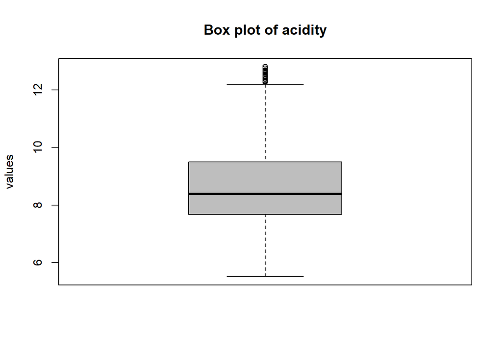

```r
boxplot(winequality.red$acidity,main="Box plot of acidity", col="gray",ylab="values")
```

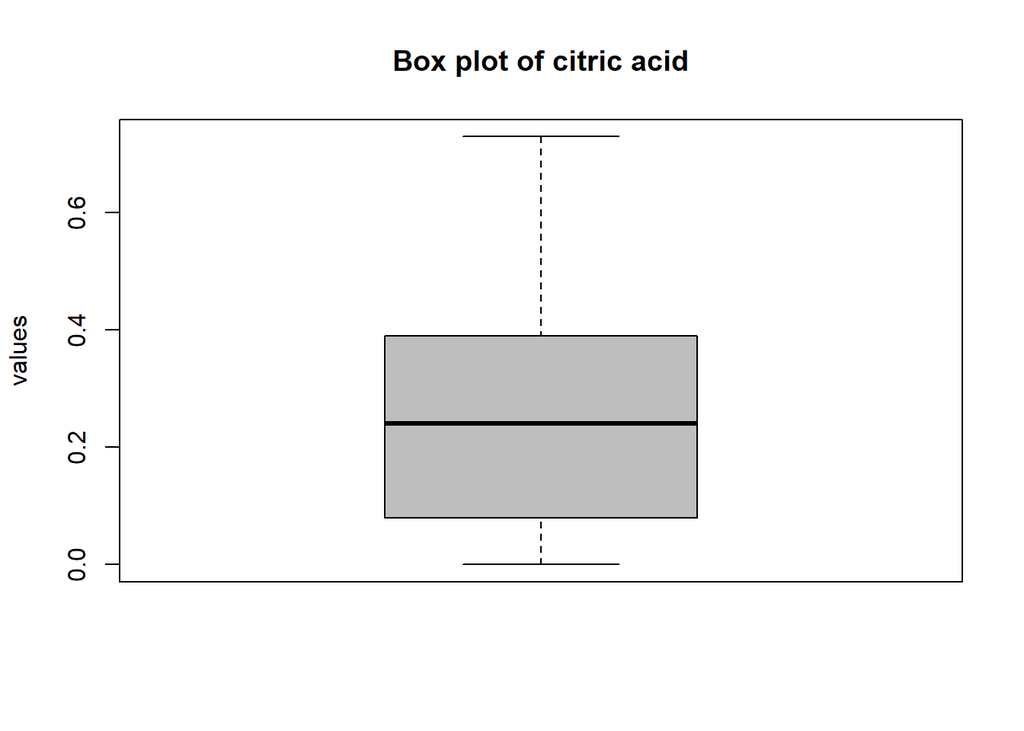

```r
boxplot(winequality.red$citric.acid,main="Box plot of citric acid", col="gray",ylab="values")
```

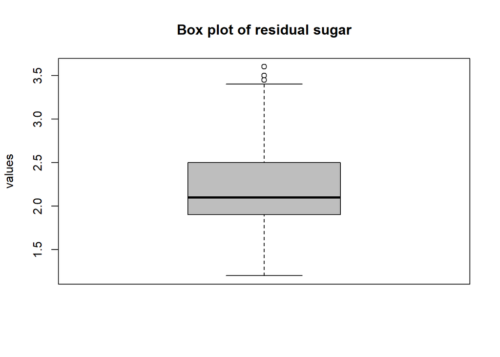

```r
boxplot(winequality.red$residual.sugar,main="Box plot of residual sugar", col="gray",ylab="values")
```

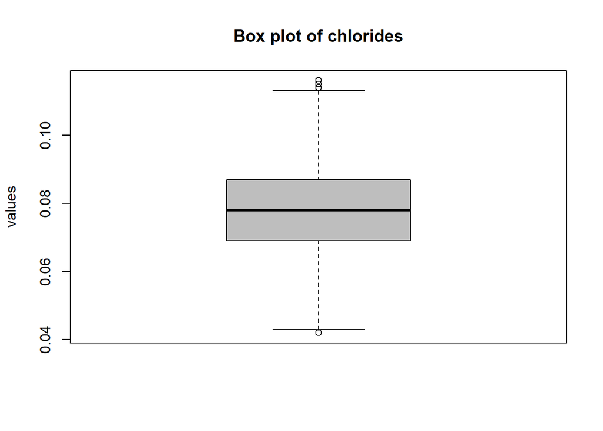

```r
boxplot(winequality.red$chlorides,main="Box plot of chlorides", col="gray",ylab="values")
```

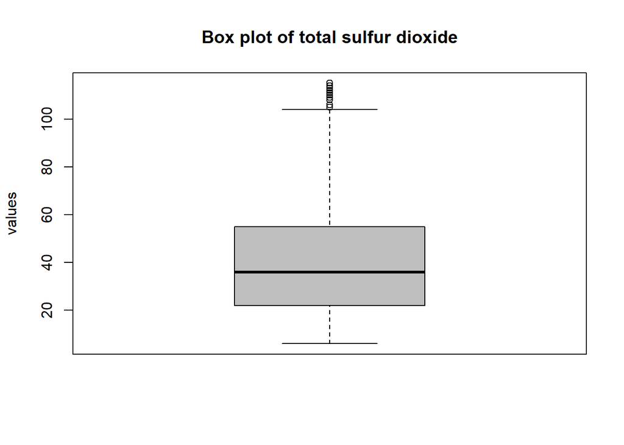

```r
boxplot(winequality.red$total.sulfur.dioxide,main="Box plot of total sulfur dioxide", col="gray",ylab="values")
```

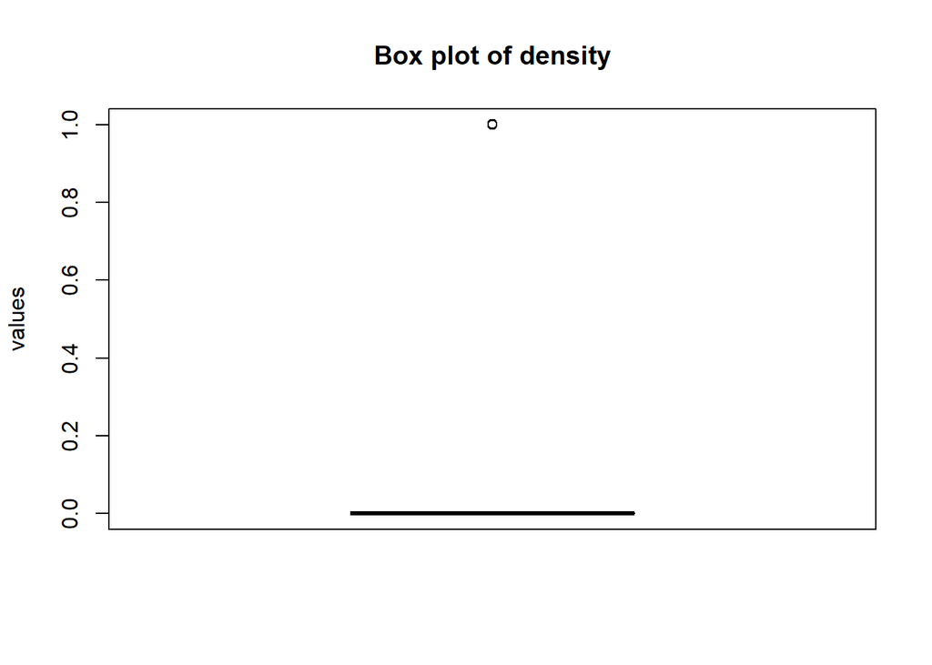

```r
boxplot(winequality.red$density,main="Box plot of density", col="gray",ylab="values")
```

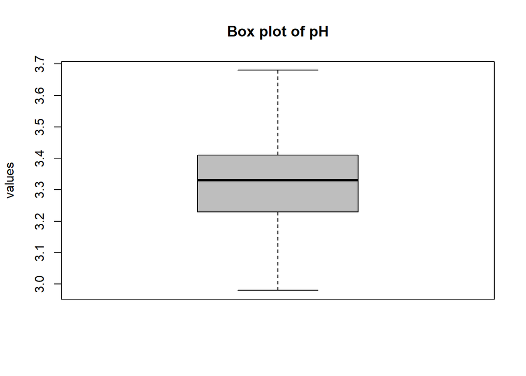

```r
boxplot(winequality.red$pH,main="Box plot of pH", col="gray",ylab="values")
```

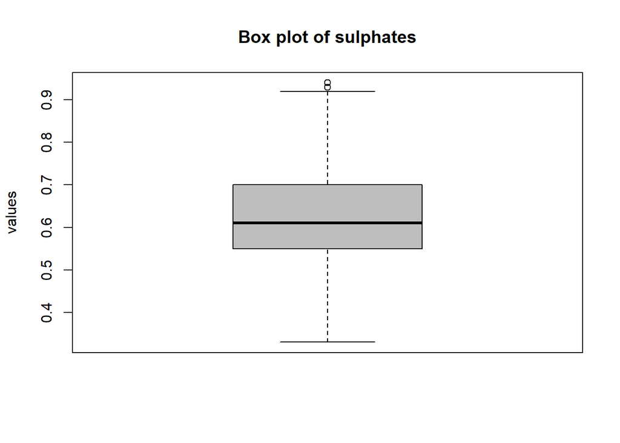

```r
boxplot(winequality.red$sulphates,main="Box plot of sulphates", col="gray",ylab="values")
```

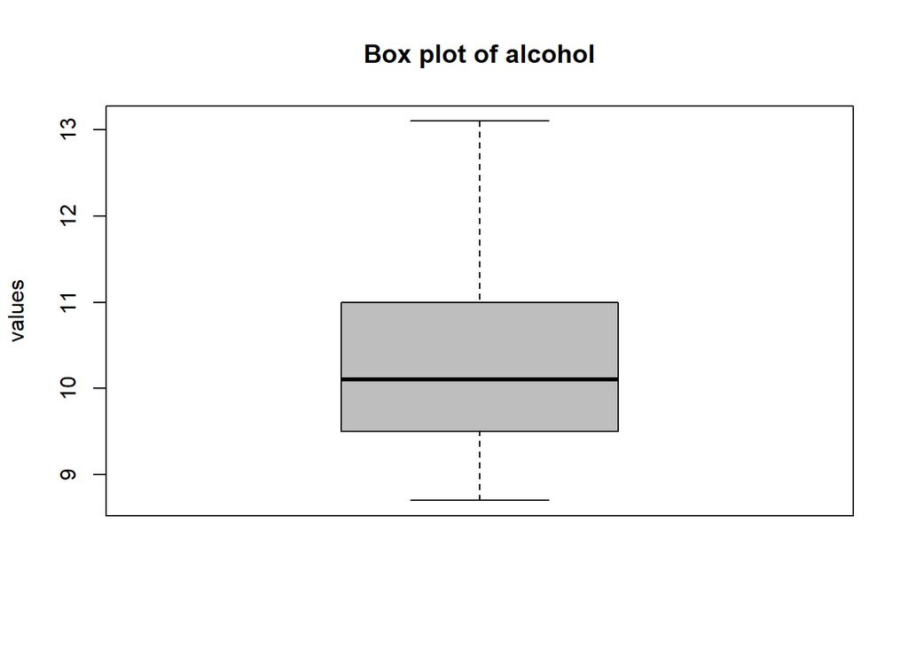

```r
boxplot(winequality.red$alcohol,main="Box plot of alcohol", col="gray",ylab="values")
```

# 5 Referencias

Squire, Megan (2015). Clean Data. Packt Publishing Ltd.

Jiawei Han, Micheine Kamber, Jian Pei (2012). Data mining: concepts and techniques. Morgan Kaufmann.

Jason W. Osborne (2010). Data Cleaning Basics: Best Practices in Dealing with Extreme Scores. Newborn and Infant Nursing Reviews; 10 (1): pp. 1527-3369.

Peter Dalgaard (2008). Introductory statistics with R. Springer Science & Business Media.

Wes McKinney (2012). Python for Data Analysis. O’Reilley Media, Inc.

Tutorial de Github (https://guides.github.com/activities/hello-world/)